# Management of Urban Soils

Naim Edwards, Nicholas Medina, Elizabeth Asker

# Introduction – Urban soils

# Introduction – Tillage

# Introduction – Cover crops

# Introduction – This study

- Research Question – How can tillage and cover crops affect urban soil functions?
- Hypothesis –
- Predictions –
  - Tillage –
    - lowers depth of hardpan soil (root-inaccessible)
    - increases –
      - water infiltration
      - yield of [rooting/tuber] crops
  - Cover crop mixes –
    - tailored toward alleviating compaction will –
      - lower hardpan depth
    - tailored toward suppressing weeds will –
      - lower weed cover, density, and richness/diversity
    - of perennials will –
      - lower hardpan depth
      - lower weed cover, density, and richness/diversity

# Methods – Study site

- Function –
  - MSU Detroit Partnership for Food Learning and Innovation (DPFLI), extension outreach, education, and demonstration center
  - Former elementary school since *2016*
- Habitat – Upland of river ~0.5 mi / 0.8 km away (42.4122141, -83.2623822)
- Soils –
  - Technosol classification, given large metal artifacts can be found from fillings during highway road construction
  - Topsoil A horizon 1-2”, subsoil B horizon “muted” yellow color
  - Heavy metal elements below EPA human hazard levels *(Table 1)* *(**EPA?**)*

    Table 1: Baseline Cornell Soil Health Assessment Lab Analysis

    | variable | n | median | mad |
    | --- | --- | --- | --- |
    | **biological** |  |  |  |
    | Organic Matter (%) | 10 | 18.950 | 4.448 |
    | Respiration (mg per day) | 10 | 6.050 | 4.374 |
    | **physical** |  |  |  |
    | Aggregate Stability (%) | 10 | 103.800 | 36.324 |
    | **chemical** |  |  |  |
    | pH | 10 | 463.600 | 24.908 |
    | Phosphorus (ppm) | 10 | 42.100 | 4.893 |
    | Potassium (ppm) | 10 | 2.250 | 1.038 |
    | **– minor** |  |  |  |
    | Iron (ppm) | 10 | 8.100 | 0.074 |
    | Magnesium (ppm) | 10 | 0.175 | 0.037 |
    | Manganese (ppm) | 10 | 2.550 | 0.297 |
    | Zinc (ppm) | 10 | 3.800 | 2.891 |

# Methods – Experimental design

- Tillage – No-, Roto-, Tractor-
- Cover crop mixes *(Table 2)*
  - Null – No manipulation
  - Perennial – vetch, clover, wheat
  - Compaction – radish, clover, ryegrass
  - Weed Suppression – cowpea, buckwheat, sorghum-sudangrass

[output not shown]

Table 2: Cover crop mixes

| Function | Plants | Binomial |
| --- | --- | --- |
| Null | Existing vegetation (no manipulation) | NA |
| Perennial | Hairy Vetch | Vicia villosa |
| Perennial | Red Clover | Trifolium pratense |
| Perennial | Wheat | Triticum aestivum |
| Compaction | Forage Radish | Raphanus sativus |
| Compaction | Crimson Clover | Trifolium incarnatum |
| Compaction | Cereal Ryegrass | Secale cereale |
| Weed Suppression | Sorghum-Sudangrass | Sorghum bicolor x S. bicolor var. sudanese |
| Weed Suppression | Cowpea | Vigna unguiculata |
| Weed Suppression | Buckwheat | Fagopyrum esculentum |

# Methods – Data collection

# Methods – Statistical analysis

- Data –
  - transferred from field, to Excel/Sheets, to R version 4.2.0 (2022-04-22)
  - centered at plot level, with median
- R packages – *rstatix* 0.7.0, *ggpubr* 0.4.0, & *tidyverse* 1.3.1
- Conservative non-parametric rank tests – Kruskal-Wallis, post-hoc Wilcoxon with *ggpubr::stat_compare_means()* for all comparisons shown
  - sampling times pooled by variable, due to negligible effects, except infiltration

# Results – Compaction

- Affected overall significantly under each cover crop mix *(Fig 1)*
  - Perennial mix showed most consistent responses
- vs. No-till –
  - Tractor *hardpan depth was higher* in Perennial and Weed Suppression mixes (significantly), as well as Null and Compaction (marginally significantly)
  - Roto-till *was lower* in Perennial mix (significantly)
- vs. Roto-till –
  - Tractor *had deeper hardpan* in Perennial mix (significantly)

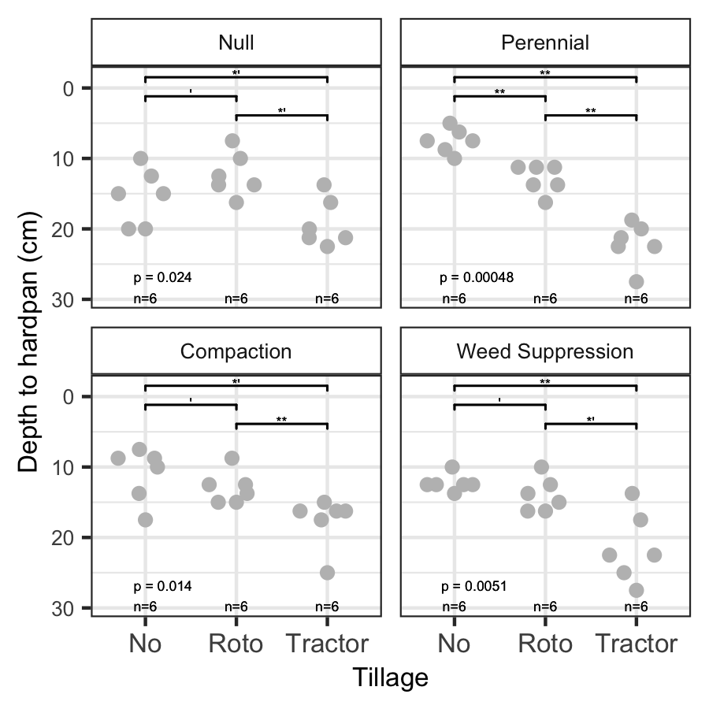

    Figure 1: Compaction data

# Results – Infiltration

- Affected overall by tillage (significantly) but not cover crop mixes *(Fig 2)*
- Roto-till showed faster infiltration vs. both No- and Tractor-till (marginally significantly) in each sampling period *(Fig 2a)*
- Weed Suppression mix independently showed higher infiltration vs. Null mix (significantly) *(Fig 2b)*

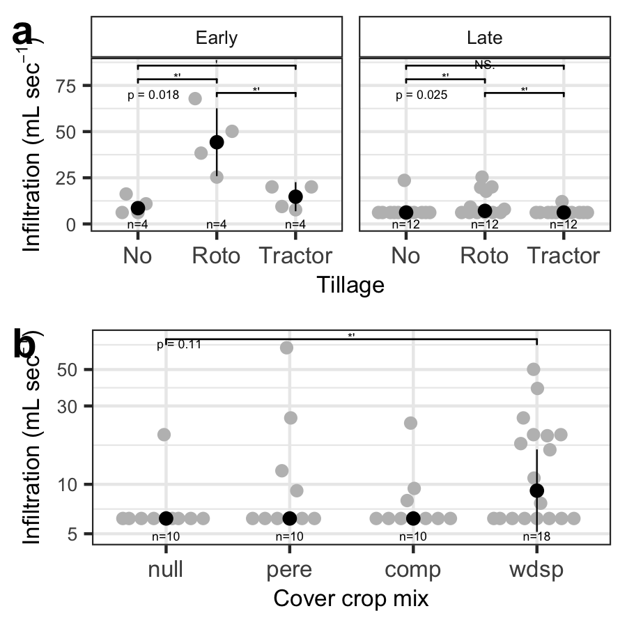

  Figure 2: Infiltration data

# Results – Weed suppression

- Affected overall more by cover crop mixes (significantly) rather than tillage *(Fig 3)*
- Tractor-till increased weed Density overall (significantly), and independently vs. both No- and Roto-till (significantly) *(Fig 3a)*
- Weed Suppression mix reduced weed Density and Richness (but less so Cover) vs. Null, Perennial, and Compaction mixes (significantly)
  - Weed Suppression did reduce weed Dover vs. Null mix (significantly)
- Both Perennial and Compaction mixes also lowered weed Density vs. Null mix (marginally significantly)

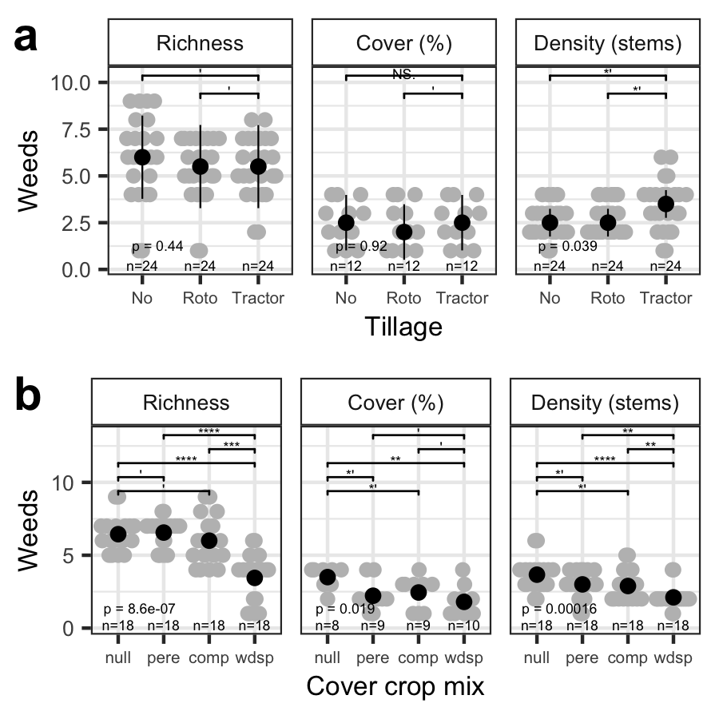

  Figure 3: Weed data

# Results – Yield

- Not affected overall by tillage *(Fig 4)*
- No-till yielded more massive radishes vs. Tractor-till (significantly)

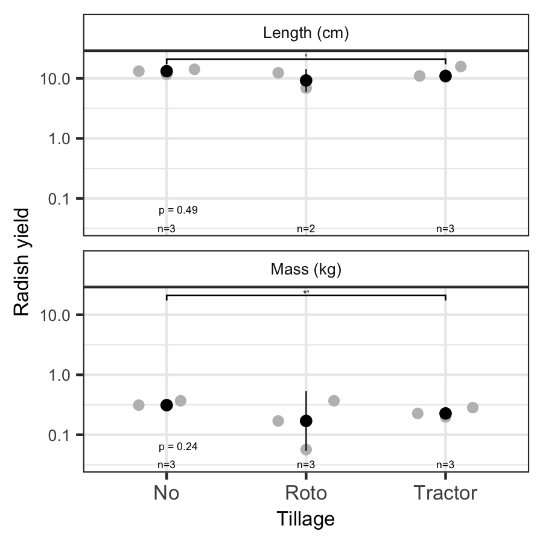

  Figure 4: Yield data

# Discussion – Hypothesis

- tillage strongest, and cover crop can follow as second
- hypothesis?
- roto-till may be most balanced approach, justifying popularity
  - relatively moderately improved compaction and infiltration
  - tractor-till sacrificed topsoil infiltration for alleviating deeper subsoil compaction
- cover crop mixes can have strongest effects on weed suppression, even while also tailored to other functions

# Discussion – Processes

- till…
- weed suppression mix effects may come from sorghum-sudangrass, since cowpea usually promotes growth via N-fixation

# Discussion – Other studies

# Discussion – Conclusion

- tillage strongest, and cover crop can follow as second
- roto-till may be most balanced approach, justifying popularity

# References

Beniston, Joshua W., Rattan Lal, and Kristin L. Mercer. 2016. “Assessing and Managing Soil Quality for Urban Agriculture in a Degraded Vacant Lot Soil.” *Land Degradation and Development* 27 (4): 996–1006. https://doi.org/10.1002/ldr.2342.

Kumar, Kuldip, and Lakhwinder S. Hundal. 2016. “Soil in the City: Sustainably Improving Urban Soils.” *Journal of Environmental Quality* 45 (1): 2–8. https://doi.org/10.2134/jeq2015.11.0589.

Stewart, Catherine E., Keith Paustian, Richard T. Conant, Alain F. Plante, and Johan Six. 2007. “Soil Carbon Saturation: Concept, Evidence and Evaluation.” *Biogeochemistry* 86 (1): 19–31. https://doi.org/10.1007/s10533-007-9140-0.